# Regression discontinuity

Mark Deming

2025-03-27

## Overview

Regression discontinuity is all about **research design** rather than econometric technique. We want to estimate a causal effect, but randomization is not possible. If assignment to treatment is based on a rule or cutoff (i.e., a **discontinuity**), we can leverage “as if” randomization to estimate a causal effect.

**Key intuition:**

- Treatment assignment is based on a rule.
- We compare observations just above and below the cutoff.
- We think of observations near the cutoff “as if” randomly assigned to treatment.
- Any discontinuity created by the rule helps us estimate the causal effect. Units just below the cutoff are valid **counterfactuals** for units just above it.

## Sharp vs. fuzzy discontinuity

In **sharp RD**, the rule is strictly followed. For example, imagine that students who score 80 or higher on an exam receive a scholarship. Those who score 79 or lower do not. If the rule is strictly followed in practice, then we are dealing with sharp RD.

In **fuzzy RD**, the rule is not strictly followed. It influences treatment but does not completely determine treatment. Returning to our test scores example, perhaps most students who score 80 or higher receive a scholarship, but not all. And, perhaps some students who score 79 or lower still receive a scholarship. The **probability** of getting the treatment (here, a scholarship) jumps at the cutoff, but it is not a perfect rule. This is a fuzzy RD.

Put differently, if crossing the the cutoff is not the *only* cause of receiving treatment, then we are dealing with fuzzy RD.

**Key differences: Sharp vs. fuzzy RD**

| Feature | Sharp RD | Fuzzy RD |
| --- | --- | --- |
| Rule at cutoff | Always followed | Often followed, but not perfectly |
| Treatment assignment | Determined only by the cutoff | Influenced by the cutoff |
| Treatment status | Jumps from 0 to 1 exactly at cutoff | Probability of treatment increases at cutoff |
| Effect estimated | Treatment effect directly | Needs special techniques (like IV) |

## Example in R

This example is from University College London’s (UCL) PUBL0050 course on *Causal Inference*: [Link](https://uclspp.github.io/PUBL0050/lectures/upload/lecture9.pdf)

But does this reflect a causal relationship? A key challenge is that municipalities where Islamic parties won may differ in important ways from those where they lost. Meyersson’s solution is to focus on municipalities where Islamic parties barely won or barely lost. Why? In very close elections, the outcome is essentially random — small chance events decide who wins.

**Setup**

```r
# Load packages
library(readr)
library(rdd)
library(modelsummary)
library(tidyverse)
library(ggthemes)

# Grad Meyerrson data from GitHub
url <- "https://raw.githubusercontent.com/UCLSPP/datasets/refs/heads/master/data/islamic_women.csv"
islamic <- read_csv(url(url))
```

Here is a description of variables:

`margin`: Islamic party margin. > 0 denotes Islamic party win. < 0 denotes Islamic party loss. `school_men`: secondary school completion rate for men aged 15-20. `school_women`: secondary school completion rate for women aged 15-20. `log_pop`: log of municipality population in 1994. `sex_ratio`: sex ratio of municipality in 1994. `log_area`: log of municipality area in 1994.

**Create treatment**

```r
# Create the treatment variable
islamic$islamic_win <- as.numeric(islamic$margin > 0)

# Tabulate the treatment variable
table(islamic$islamic_win)
```

```
##
##    0    1
## 2332  328
```

The Islamic party won 328 municipalities.

**Difference in means**

```r
# Difference in means
diff_in_means <- mean(islamic$school_women[islamic$islamic_win==1],na.rm=T) -
  mean(islamic$school_women[islamic$islamic_win==0],na.rm=T)

diff_in_means
```

```
## [1] -0.02577901
```

Difference in means is -0.026. Across all municipalities, Islamic party government is associated with lower female education rates. This is **not a credible estimate** of the causal effect of Islamic party government on female education. For one, places that strongly support Islamic parties are probably less supportive of female education to begin with.

**Select a bandwidth**

```r
band <- IKbandwidth(islamic$margin, islamic$school_women)
band
```

```
## [1] 0.2398152
```

`IKbandwidth` calculates the Imbens-Kalyanaraman optimal bandwidth for local linear regression in RDD. The result indicates that the optimal bias-variance trade-off is achieved for this specific RD by only including municipalities where there vote share margin for the Islamic party was -0.239 to 0.239.

**Grab units within bandwidth**

```r
islamic_rdd <- islamic %>%
  filter(abs(margin) < band)

# Alternatively
# islamic_rdd  <- islamic[abs(islamic$margin) < band , ]
```

**Run linear regression to find LATE**

```r
# model
linear_rdd_model <- lm(school_women ~ margin + islamic_win,
                       data=islamic_rdd)
# regression table
modelsummary::modelsummary(linear_rdd_model,
                           output = "markdown")
```

|  | (1) |
| --- | --- |
| (Intercept) | 0.128 |
|  | (0.006) |
| margin | -0.221 |
|  | (0.045) |
| islamic_win | 0.033 |
|  | (0.011) |
| Num.Obs. | 1020 |
| R2 | 0.026 |
| R2 Adj. | 0.025 |
| AIC | -1939.3 |
| BIC | -1919.6 |
| Log.Lik. | 973.631 |
| F | 13.814 |
| RMSE | 0.09 |

The regression indicates a local average treatment effect (LATE) of .033. This is not very credible because it assumes that the slope is the same on either side of the cutoff. To see this, let’s create a plot:

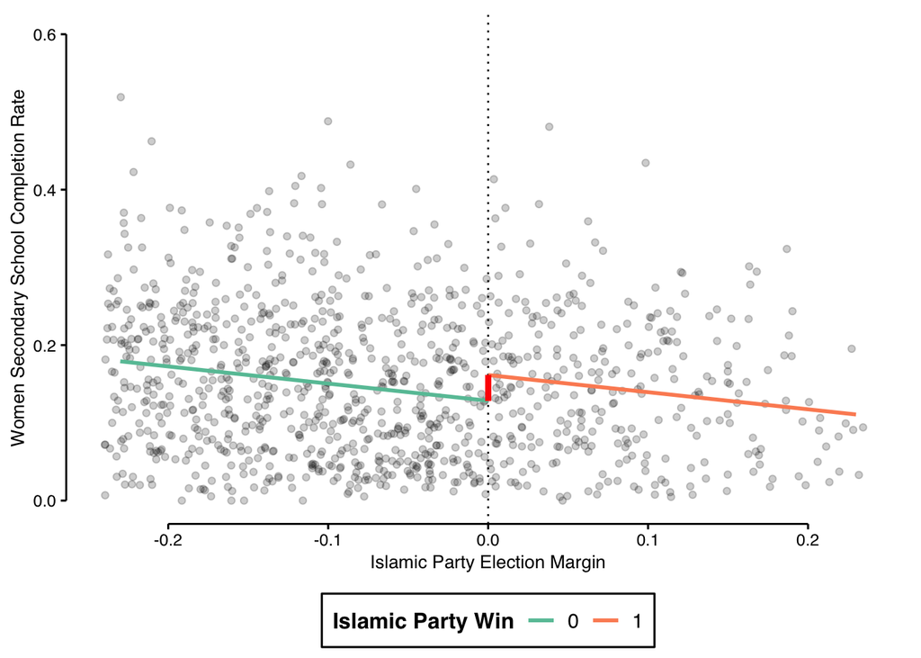

```r
# plotting the relationship
## predicted values control
control <- data.frame(margin = seq(-round(band,2),0,.01), islamic_win = 0)
control$pred <- predict(linear_rdd_model, newdata = control)
## predicted values treated
treated <- data.frame(margin = seq(0,round(band,2),.01), islamic_win = 1)
treated$pred <- predict(linear_rdd_model, newdata = treated)
## combine
pred <- rbind(control,treated)
pred$islamic_win <- as.factor(pred$islamic_win)
## plot
ggplot(islamic, aes(x = margin, y = school_women)) +
  geom_point(alpha=.2) + # observed data
  geom_vline(xintercept=0,linetype="dotted") + # vertical line at cutoff
  geom_line(data = pred, aes(y = pred, color = islamic_win), linewidth = 1) + # regression line on either side of cutoff
  geom_segment(x = 0, xend =  0,
               y = pred$pred[pred$margin == 0 & pred$islamic_win == 0], yend = pred$pred[pred$margin == 0 & pred$islamic_win == 1],
               linewidth = 1.5, color = "red") + # vertical line for LATE
  scale_y_continuous("Women Secondary School Completion Rate", limits = c(0,.6)) +
  scale_x_continuous("Islamic Party Election Margin", limits = c(-band, band)) +
  scale_colour_brewer("Islamic Party Win", palette = "Set2") +
  theme_clean() +
  lemon::coord_capped_cart(bottom="both",left="both") +
  theme(plot.background = element_rect(color=NA),
        panel.grid.major.y = element_blank(),
        legend.position = "bottom")
```

**Run `RDestimate` to find LATE**

```r
rd_est <- RDestimate(school_women ~ margin,
                       cutpoint = 0, bw = band, data = islamic)
summary(rd_est)
```

```
##
## Call:
## RDestimate(formula = school_women ~ margin, data = islamic, cutpoint = 0,
##     bw = band)
##
## Type:
## sharp
##
## Estimates:
##            Bandwidth  Observations  Estimate  Std. Error  z value  Pr(>|z|)
## LATE       0.2398     1020          0.02963   0.01241     2.388    0.01694   *
## Half-BW    0.1199      589          0.02502   0.01646     1.520    0.12859
## Double-BW  0.4796     2050          0.02279   0.01009     2.257    0.02399   *
## ---
## Signif. codes:  0 '***' 0.001 '**' 0.01 '*' 0.05 '.' 0.1 ' ' 1
##
## F-statistics:
##            F       Num. DoF  Denom. DoF  p
## LATE        4.990  3         1016        3.865e-03
## Half-BW     1.703  3          585        3.304e-01
## Double-BW  25.770  3         2046        4.441e-16
```

## What treatments depend on a threshold?

RD is widely used in rule-based settings where it is clear how treatment was assigned:

- Elections (narrow races)
- Administrative programs
- Geographic boundaries

RD ultimately relies on **knowing about** and **having access** to a running variable that determines (or at least influences) treatment status.